# Exploración, Análisis y Visualización de Datos

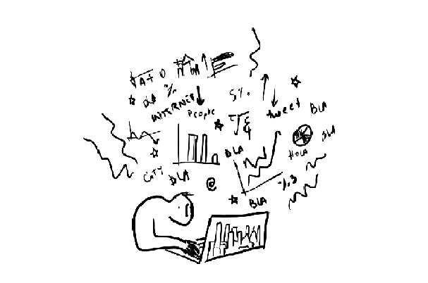

## Introducción a R

### Un poco de historia

- R es un entorno de software libre para el cálculo estadístico y generación de gráficos.
- Es un GNU proyect similar al lenguaje S que fue desarrollado en los laboratorios Bell por Jhon Chambers y colegas.
- R provee una alta variedad de estadísticas, como son: modelos lineales y no lineales, tests para estadística clásica, análisis de series de tiempo, clasificación, clustering, etc.) R es posible como software libre bajo los términos de Free Softwares Foundation’s GNU General Public License. Este compila bajo un gran variedad de UNIX platforms y sistemas similares, Windows y MacOS.

### Breve repaso de cómo funciona R

- R es un lenguaje orientado a objeto. Es por ello que resulta ser un programa flexible y de fácil de utilizar.
- Orientado a objetos significa que las variables, datos, funciones, resultados, etc., se guardan en la memoria de la computadora en forma de objetos con un nombre específico.

### Para descarga de R y Rstudio

1. [R](https://cran.r-project.org/)
2. [R Studio](https://www.rstudio.com/products/rstudio/download/) (bajar la versión Free)

R Studio es un entorno de desarrollo integrado (IDE) para la utilización del lenguaje R. Es un conjunto de herramientas integradas para obtener un uso más productivo de R.

[figure not shown]

Vista de Rstudio

[figure not shown]

### Paquetes de R

Un paquete es una colección de funciones, datos y código R que se almacenan en una carpeta conforme a una estructura bien definida, fácilmente accesible para R. Hay paquetes oficiales (disponibles en CRAN) y no oficiales (disponibles a través de plataformas como github). Actualmente el repositorio de CRAN cuenta con 22219 paquetes disponibles.

La simple instalación de R trae consigo múltiples paquetes que permiten un funcionamiento básico de importación de datos, ajuste y evaluación de modelos estadísticos y representaciones gráficas. Sin embargo, la enorme potencia de R deriva de su capacidad de incorporar nuevas funciones generadas por su gran comunidad de usuarios (ver novedades en: [r weekly](https://rweekly.org/); [r-bloggers](https://www.r-bloggers.com/); [revolution analytics](https://blog.revolutionanalytics.com/); [RStudio blog](https://blog.rstudio.com/categories/packages))

En la web de R se puede consultar la [lista de paquetes disponibles](https://cran.r-project.org/web/packages/available_packages_by_date.html), y en la sección [Task Views](https://cran.r-project.org/web/views/) se puede consultar los mismos ordenados por áreas de aplicación.

Existen distintos caminos para instalar un paquete:

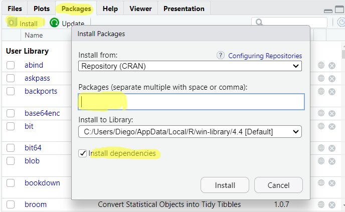

- Via CRAN (Comprehensive R Archive Network): `install.packages("nombre_del_paquete")` O simplemente en el panel de paquetes.
- Paquetes no oficiales via Github: `devtools::install_github("rstudio/epiphy")`

Una vez instalado, hay que cargar los paquetes que contienen las funciones que vayamos a usar en cada sesión

`library(nombre-del-paquete)`

### Workflow componentes

Varios tipos de archivos serán creados y usados durante una sesión de R:

- datos crudos (hojas de cálculo) - datos manipulados
- scripts
- gráficos
- reportes de resultados

Una sesión de análisis debe poder ser retomada en cualquier momento, pudiendo darse por concluída cuando el trabajo es publicado. Hasta entonces debemos tener rápido acceso a todos los objetos creados en sesiones anteriores. Para ello debemos manejarnos siempre bajo *buenas prácticas* de trabajo. Esto nos permitirá entender que quisimos hacer tiempo atrás, seremos intuitivos para encontrar archivos/objetos, y finalmente crearemos trabajos *reproducibles*…  
Una forma práctica de administrar todos los objetos que una sesión es crear un proyecto de R para cada sesión.

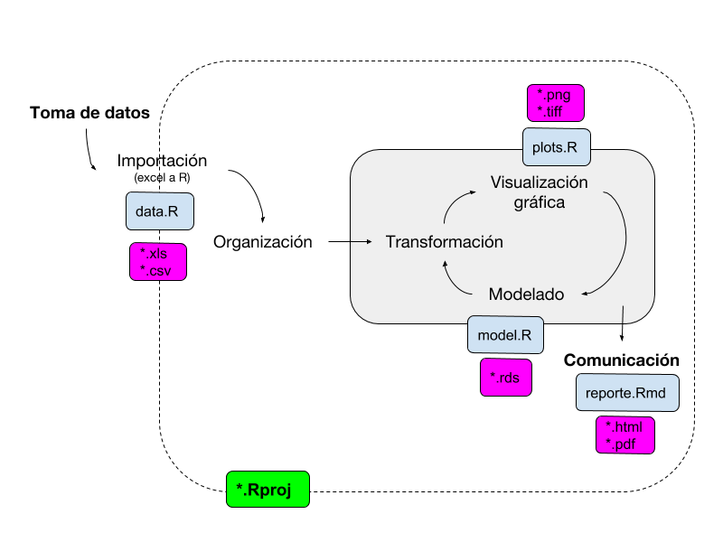